# Changement de mode de définition

Jusqu’à présent, nous avions défini notre approche classique autour de l’approximation classique pour montrer la capacité d’approximation des modèles. On voulait montrer leur capacité d’approximation, mais ces théories ne sont que des approches théoriques parfaites, sans données imparfaites, sans erreurs de classification. Les classifications réelles sont loin des données parfaites que l’on cherche à traiter.

Pour ce faire, nous allons reprendre le modèle de base mai l'orienbté pour l'approxmation :

```python
from source.quantum_circuit import *
import matplotlib.pyplot as plt

import numpy as np

quantum_circuit.add_door("G", "RX(v)")

# On définit S(X)

quantum_circuit.add_door("S", "G(v)")

# On définit W(theta)

quantum_circuit.add_door("W", "RZ(v)-RY(v)-RZ(v)")

quantum_circuit.add_door("L", "W(v,v,v)-S(v)")

class AdamOptimizer:
    def __init__(
        self,
        learning_rate=0.01,
        beta1=0.9,
        beta2=0.999,
        epsilon=1e-8,
        delta=1e-5,
        acc_weight=0.5
    ):

        self.lr = learning_rate
        self.beta1 = beta1
        self.beta2 = beta2
        self.epsilon = epsilon
        self.delta = delta
        self.acc_weight = acc_weight

        self.t = 0
        self.m = None
        self.v = None

    def compute_gradient(self, f, w):
        grad = np.zeros_like(w)
        # gradient par différence finie
        for idx in np.ndindex(w.shape):
            w_p = w.copy(); w_m = w.copy()
            w_p[idx] += self.delta
            w_m[idx] -= self.delta
            grad[idx] = (f(w_p) - f(w_m)) / (2 * self.delta)
        return grad

    def step(self, f_loss, w, f_acc=None):

        # premier appel : init m et v
        if self.m is None:
            self.m = np.zeros_like(w)
            self.v = np.zeros_like(w)

        self.t += 1

        # construction de l'objectif global
        if f_acc is None:
            def objective(wg):
                return f_loss(wg)
        else:
            def objective(wg):
                # on soustrait accuracy pour la maximiser
                return f_loss(wg) - self.acc_weight * f_acc(wg)

        # calcul du gradient
        grad = self.compute_gradient(objective, w)

        # moments Adam
        self.m = self.beta1 * self.m + (1 - self.beta1) * grad
        self.v = self.beta2 * self.v + (1 - self.beta2) * (grad ** 2)

        # bias-correction
        m_corr = self.m / (1 - self.beta1**self.t)
        v_corr = self.v / (1 - self.beta2**self.t)

        # mise à jour
        w_new = w - self.lr * m_corr / (np.sqrt(v_corr) + self.epsilon)
        return w_new


class QuantumModel:

    def __init__(self, circuit, gamma):

        self.circuit = circuit

        # Comptage dynamique du nombre de couches représenté par la forme "v,v,v"
        self.num_layers = len(re.findall(r"v(?:\s*,\s*v){2}", circuit))

        self.gamma = gamma
        self.weights = 0.1 * np.random.randn(self.num_layers,3)
        quantum_circuit(circuit.replace('x', 'v')).draw()


    # interface d'utilisation du simulateur
    def _simulate_circuit(self, x, weights):
        circuit = self.circuit  # nom raccourci
        # on crée la version pour le simulateur
        circuit_str = circuit.replace('x', 'v')
        simulator = quantum_circuit(circuit_str)
        flat_weights = weights.flatten()

        # on itère sur les occurences de v ou x, avec leur position dans la chaîne
        matches = list(re.finditer(r"[vx]", circuit))
        replacement_values = []
        weight_index = 0

        for idx, match in enumerate(matches):
            token = match.group()         # 'v' ou 'x'
            pos   = match.start()         # position caractère dans circuit
            line_no = circuit_str[:pos].count("\n")

            if token == 'x':
                # gamma * x[line_no] : line_no ∈ {0,1,..., len(x)-1}
                val = float(self.gamma * x[line_no-1])
            else:
                val = float(flat_weights[weight_index])
                weight_index += 1

            replacement_values.append(val)

        # on envoie dans le simulateur
        simulator.replace_values(replacement_values)
        qubits = simulator.apply_circuit()
        mesure = np.sum([np.real(np.vdot(q, quantum_door.Pauli_Z(q))) for q in qubits])
        return mesure

    # fonction de forward dans le ciruit
    def forward(self, x):
        outputs = []
        # On place tous les x dans le circuit, les uns après les autres, pour l'entraînement
        for x_i in x:
            outputs.append(self._simulate_circuit(x_i, self.weights))
        return np.array(outputs)

    def square_loss(self, targets, predictions):
        loss = np.mean((targets - predictions)**2)
        return 0.5 * loss

    def compute_loss(self, x_batch, y_batch, weights=None):
        if weights is None:
            weights = self.weights

        preds = []

        # Application du circuit sur chaque élément de x_batch
        for x_i in x_batch:
            preds.append(self._simulate_circuit(x_i, weights))

        # Retourne la perte quadratique
        return self.square_loss(y_batch, preds)

    def load_weights(self, weights):
        self.weights = weights.copy()


    def accuracy(self,targets, predictions, threshold=0.1):
        correct = np.sum(np.abs(targets - predictions) < threshold)
        return correct / len(targets)

    def train(self, x, y, steps=1000, learning_rate=0.3, batch_size=25):

        optimizer = AdamOptimizer(learning_rate=learning_rate)
        cost_history = []
        accuracy_history = []
        max_accuracy = 0
        save_weight = self.weights.copy()

        for step in range(steps):
            idx = np.random.choice(len(x), batch_size, replace=False)
            xb, yb = x[idx], y[idx]

            def loss_closure(w):
                return self.compute_loss(xb, yb, weights=w)

            self.weights = optimizer.step(loss_closure, self.weights)

            loss_value = loss_closure(self.weights)
            preds = np.array([self._simulate_circuit(xi, self.weights) for xi in xb])
            acc_value = self.accuracy(yb, preds)

            if (max_accuracy < acc_value):
                save_weight = self.weights.copy()


            cost_history.append(loss_value)
            accuracy_history.append(acc_value)

            print(f"Step {step+1:4d}: Loss = {loss_value:.6f}, Accuracy = {acc_value:.2%}")

        plt.figure(figsize=(12, 5))

        plt.subplot(1, 2, 1)
        plt.plot(cost_history, label="Loss", linewidth=2, color="navy")
        plt.title("Évolution de la Loss")
        plt.xlabel("Itération")
        plt.ylabel("MSE")
        plt.legend()

        plt.subplot(1, 2, 2)
        plt.plot(accuracy_history, label="Accuracy", linewidth=2, color="green")
        plt.title("Évolution de l'Accuracy")
        plt.xlabel("Itération")
        plt.ylabel("Accuracy")
        plt.ylim(0, 1)
        plt.legend()

        best_step = accuracy_history.index(max(accuracy_history))
        plt.scatter(best_step, accuracy_history[best_step], color="red", label="Poids sauvegardé", zorder=3)

        plt.tight_layout()
        plt.show()


        self.weight = save_weight.copy()
```

# Regression sur le dataset diabetes de scikit-learn avec un seul qubit

Dans cette section, nous allons étudier l’approximation du jeu de données « diabetes » de scikit-learn. Comme une modélisation directe peut s’avérer complexe, nous utiliserons une régression polynomiale dotée d’un critère de convergence. En faisant varier le degré du polynôme et en fixant un seuil d’erreur à ne pas dépasser, nous pourrons à la fois contrôler la complexité du modèle et renforcer notre exigence sur la qualité de l’approximation.

Nous allons ajuster une régression polynomiale de degré 3 sur le jeu de données diabetes de scikit-learn afin d’obtenir une fonction analytique simple qui modélise la relation entre la composante principale (issue d’une PCA 1D) et la variable cible.

Ce modèle polynomial, à la fois léger et transparent, joue le rôle d’un réseau de neurones simplifié : il illustre comment un simple polynôme peut apprendre une tendance sous-jacente avant de passer à des architectures plus complexes comme les réseaux profonds.

```
--- Circuit ---
|0⟩—[L(0j,—0j,—0j,—0j)]—[L(0j,—0j,—0j,—0j)]—[L(0j,—0j,—0j,—0j)]—[W(0j,—0j,—0j)]—> M

Step    1: Loss = 0.612519, Accuracy = 0.00%
Step    2: Loss = 0.410928, Accuracy = 0.00%
Step    3: Loss = 0.275450, Accuracy = 16.00%
Step    4: Loss = 0.409954, Accuracy = 0.00%
Step    5: Loss = 0.403405, Accuracy = 0.00%
Step    6: Loss = 0.410189, Accuracy = 4.00%
Step    7: Loss = 0.473555, Accuracy = 0.00%
Step    8: Loss = 0.305826, Accuracy = 0.00%
Step    9: Loss = 0.191955, Accuracy = 0.00%
Step   10: Loss = 0.127171, Accuracy = 0.00%
Step   11: Loss = 0.075441, Accuracy = 8.00%
Step   12: Loss = 0.024639, Accuracy = 4.00%
Step   13: Loss = 0.019962, Accuracy = 56.00%
Step   14: Loss = 0.020561, Accuracy = 60.00%
Step   15: Loss = 0.037448, Accuracy = 12.00%
Step   16: Loss = 0.049780, Accuracy = 12.00%
Step   17: Loss = 0.063507, Accuracy = 12.00%
Step   18: Loss = 0.075445, Accuracy = 8.00%
Step   19: Loss = 0.089226, Accuracy = 8.00%
Step   20: Loss = 0.063085, Accuracy = 8.00%
Step   21: Loss = 0.050287, Accuracy = 4.00%
Step   22: Loss = 0.044828, Accuracy = 16.00%
Step   23: Loss = 0.029766, Accuracy = 32.00%
Step   24: Loss = 0.017388, Accuracy = 36.00%
Step   25: Loss = 0.028839, Accuracy = 16.00%
Step   26: Loss = 0.019822, Accuracy = 24.00%
Step   27: Loss = 0.015590, Accuracy = 36.00%
Step   28: Loss = 0.022780, Accuracy = 36.00%
Step   29: Loss = 0.019903, Accuracy = 40.00%
Step   30: Loss = 0.023299, Accuracy = 36.00%
Step   31: Loss = 0.015664, Accuracy = 36.00%
Step   32: Loss = 0.017608, Accuracy = 20.00%
Step   33: Loss = 0.012325, Accuracy = 12.00%
Step   34: Loss = 0.015631, Accuracy = 20.00%
Step   35: Loss = 0.009518, Accuracy = 36.00%
Step   36: Loss = 0.008162, Accuracy = 32.00%
Step   37: Loss = 0.005657, Accuracy = 92.00%
```

[output cut: 48 more lines]

```
Step   86: Loss = 0.001497, Accuracy = 96.00%
Step   87: Loss = 0.001181, Accuracy = 100.00%
Step   88: Loss = 0.001903, Accuracy = 92.00%
Step   89: Loss = 0.001213, Accuracy = 96.00%
Step   90: Loss = 0.000923, Accuracy = 96.00%
Step   91: Loss = 0.001034, Accuracy = 96.00%
Step   92: Loss = 0.001127, Accuracy = 96.00%
Step   93: Loss = 0.001913, Accuracy = 88.00%
Step   94: Loss = 0.000896, Accuracy = 92.00%
Step   95: Loss = 0.000831, Accuracy = 96.00%
Step   96: Loss = 0.001326, Accuracy = 96.00%
Step   97: Loss = 0.002155, Accuracy = 92.00%
Step   98: Loss = 0.002268, Accuracy = 92.00%
Step   99: Loss = 0.001796, Accuracy = 100.00%
Step  100: Loss = 0.001412, Accuracy = 100.00%
```

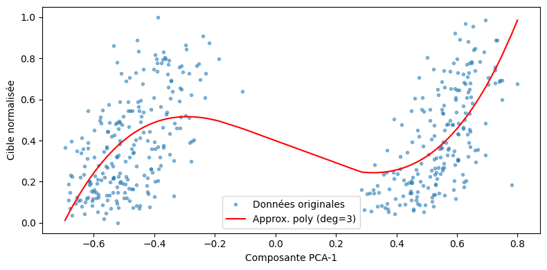

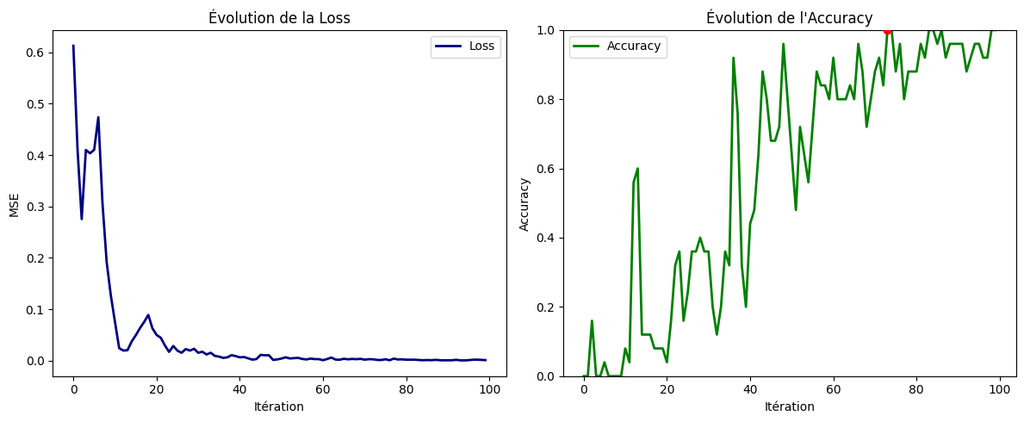

```python
import numpy as np
import matplotlib.pyplot as plt
from sklearn.datasets import load_diabetes
from sklearn.preprocessing import MinMaxScaler
from sklearn.decomposition import PCA

# on charge et normalise les données.
X, y = load_diabetes(return_X_y=True)
scaler_X = MinMaxScaler()
scaler_y = MinMaxScaler()
X = scaler_X.fit_transform(X)
y = scaler_y.fit_transform(y.reshape(-1, 1)).ravel()

# on réduit à une seule dimension via PCA et on trie les points.
X1 = PCA(n_components=1).fit_transform(X).ravel()
order = np.argsort(X1)
X1, y = X1[order], y[order]

# on approxime la relation par régression polynomiale de degré 3.
degree = 3
coeffs = np.polyfit(X1, y, deg=degree)
poly = np.poly1d(coeffs)
y_approx = poly(X1)

# on visualise l’original vs. l’approché.
plt.figure(figsize=(8, 4))
plt.plot(X1, y, '.', alpha=0.5, label='Données originales')
plt.plot(X1, y_approx, '-', color='red',
         label=f'Approx. poly (deg={degree})')
plt.xlabel('Composante PCA-1')
plt.ylabel('Cible normalisée')
plt.legend()
plt.tight_layout()
# plt.show()

# on entraîne le modèle quantique sur la cible approchée.
circuit = "L(v,v,v,x)-" * 3 + "W(v,v,v)"
gamma = 2
model = QuantumModel(circuit, gamma)
model.train(
    X1.reshape(-1, 1),
    y_approx,
    steps=100,
    learning_rate=0.1,
    batch_size=25
)
```

# Visualisation classique de l'approximation de la fonction de classification :

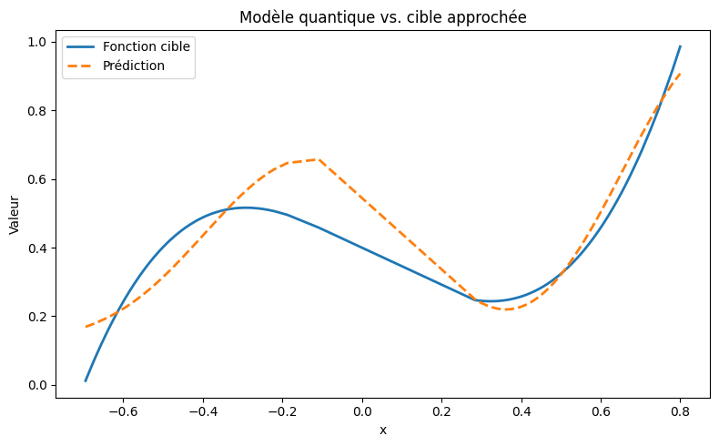

```python
import numpy as np
import matplotlib.pyplot as plt

def plot_function_comparison(model, x, y, title="Approximation de la fonction"):
    x = np.array(x).ravel()
    X_in = x.reshape(-1, 1)
    y_pred = model.forward(X_in).ravel()

    plt.figure(figsize=(8, 5))
    plt.plot(x, y,       label="Fonction cible", linewidth=2)
    plt.plot(x, y_pred, '--', label="Prédiction",     linewidth=2)
    plt.title(title)
    plt.xlabel("x")
    plt.ylabel("Valeur")
    plt.legend()
    plt.tight_layout()
    plt.show()

plot_function_comparison(model, X1, y_approx,
                         title="Modèle quantique vs. cible approchée")
```

# Fonction d’Approximation Quantique

L’intérêt majeur de cette méthode réside dans sa scalabilité : en mobilisant un seul qubit pour représenter une unique caractéristique, chaque qubit agit comme un maillon dans une chaîne d’approximation entre les éléments du dataset. Grâce à cette architecture, il devient possible de tisser des liens quantiques entre les données, facilitant ainsi une modélisation plus efficace et plus profonde des relations présentes dans le dataset.

## Avantages Concrets

- **Réduction de la complexité**  
  en répartissant la tâche entre plusieurs qubits, on diminue la taille de chaque sous-problème et on améliore la compréhensibilité de ces aspects, tout en conservant un niveau d’analyse équivalent.
- **Prise en charge de fonctions complexes**  
  on peut intégrer des formules non linéaires, comme $\frac{x_1}{x_2}$, $x_1^2 \sin(x_2)$ ou d’autres combinaisons, pour capturer des interactions fines et enrichir l’approximation.
- **Amélioration de la généralisation**  
  les interconnexions quantiques entre qubits permettent de détecter des tendances et des régularités plus subtiles qu’avec des méthodes classiques.
- **Exploration intuitive du dataset**  
  chaque qubit servant de proxy pour une caractéristique facilite une navigation plus fluide à travers les données, mettant en lumière des corrélations invisibles autrement.

En somme, cette méthode ne se contente pas d’approximer les résultats : elle propose une nouvelle manière de structurer et d’interpréter les données, en tirant parti du potentiel unique de l’informatique quantique pour l’analyse et la compréhension des ensembles complexes.

# Approximation du dataset diabete avec deux qubits

Mais on peut aussi approximer la fonction à deux variables pour complexifier la structure et rendre plus aisée la compréhension du circuit, avec une augmentation du degré pour approximer la relation de manière plus complexe.

```
--- Circuit ---
|0⟩—[L(0j,—0j,—0j,—0j)]—[L(0j,—0j,—0j,—0j)]—[L(0j,—0j,—0j,—0j)]—> M
|1⟩—[L(0j,—0j,—0j,—0j)]—[L(0j,—0j,—0j,—0j)]—[L(0j,—0j,—0j,—0j)]—> M

Step    1: Loss = 0.548231, Accuracy = 0.00%
Step    2: Loss = 0.339960, Accuracy = 8.00%
Step    3: Loss = 0.180548, Accuracy = 8.00%
Step    4: Loss = 0.226237, Accuracy = 8.00%
Step    5: Loss = 0.166504, Accuracy = 8.00%
Step    6: Loss = 0.181685, Accuracy = 24.00%
Step    7: Loss = 0.180148, Accuracy = 4.00%
Step    8: Loss = 0.150358, Accuracy = 0.00%
Step    9: Loss = 0.070874, Accuracy = 24.00%
Step   10: Loss = 0.022012, Accuracy = 28.00%
Step   11: Loss = 0.074548, Accuracy = 8.00%
Step   12: Loss = 0.062875, Accuracy = 16.00%
Step   13: Loss = 0.093888, Accuracy = 8.00%
Step   14: Loss = 0.067677, Accuracy = 4.00%
Step   15: Loss = 0.041732, Accuracy = 20.00%
Step   16: Loss = 0.024560, Accuracy = 40.00%
Step   17: Loss = 0.014330, Accuracy = 60.00%
Step   18: Loss = 0.032171, Accuracy = 44.00%
Step   19: Loss = 0.010001, Accuracy = 60.00%
Step   20: Loss = 0.019434, Accuracy = 48.00%
Step   21: Loss = 0.025944, Accuracy = 60.00%
Step   22: Loss = 0.014385, Accuracy = 48.00%
Step   23: Loss = 0.005877, Accuracy = 64.00%
Step   24: Loss = 0.007534, Accuracy = 68.00%
Step   25: Loss = 0.004346, Accuracy = 76.00%
Step   26: Loss = 0.014645, Accuracy = 32.00%
Step   27: Loss = 0.005512, Accuracy = 60.00%
Step   28: Loss = 0.005759, Accuracy = 40.00%
Step   29: Loss = 0.007489, Accuracy = 48.00%
Step   30: Loss = 0.006093, Accuracy = 56.00%
Step   31: Loss = 0.004361, Accuracy = 76.00%
Step   32: Loss = 0.006204, Accuracy = 64.00%
Step   33: Loss = 0.003495, Accuracy = 72.00%
Step   34: Loss = 0.003543, Accuracy = 76.00%
Step   35: Loss = 0.003821, Accuracy = 80.00%
Step   36: Loss = 0.003063, Accuracy = 76.00%
```

[output cut: 49 more lines]

```
Step   86: Loss = 0.001915, Accuracy = 92.00%
Step   87: Loss = 0.003250, Accuracy = 84.00%
Step   88: Loss = 0.001375, Accuracy = 96.00%
Step   89: Loss = 0.001244, Accuracy = 92.00%
Step   90: Loss = 0.002311, Accuracy = 84.00%
Step   91: Loss = 0.000948, Accuracy = 92.00%
Step   92: Loss = 0.003334, Accuracy = 84.00%
Step   93: Loss = 0.001608, Accuracy = 92.00%
Step   94: Loss = 0.006731, Accuracy = 88.00%
Step   95: Loss = 0.003522, Accuracy = 84.00%
Step   96: Loss = 0.002486, Accuracy = 84.00%
Step   97: Loss = 0.001361, Accuracy = 96.00%
Step   98: Loss = 0.002569, Accuracy = 88.00%
Step   99: Loss = 0.002299, Accuracy = 92.00%
Step  100: Loss = 0.002907, Accuracy = 80.00%
```

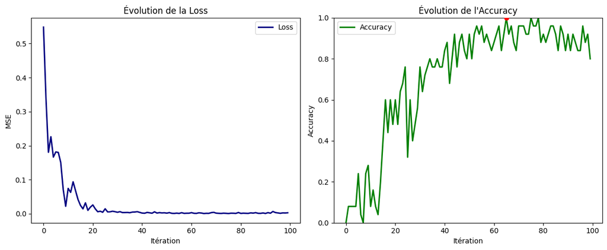

```python
import numpy as np
import matplotlib.pyplot as plt
from sklearn.datasets import fetch_california_housing
from sklearn.preprocessing import MinMaxScaler, PolynomialFeatures
from sklearn.decomposition import PCA
from sklearn.linear_model import LinearRegression

# on charge et normalise les données
X, y = load_diabetes(return_X_y=True)
X = MinMaxScaler().fit_transform(X)
y = MinMaxScaler().fit_transform(y.reshape(-1, 1)).ravel()

# on réduit à deux dimensions via PCA
X2 = PCA(n_components=2).fit_transform(X)

# on génère des features polynomiales de degré 3 et on ajuste la régression
poly_feat = PolynomialFeatures(degree=5, include_bias=False)
X_poly   = poly_feat.fit_transform(X2)
linreg   = LinearRegression().fit(X_poly, y)
y_approx = linreg.predict(X_poly)

# on visualise l’approximation sous forme de contour
x1_lin = np.linspace(X2[:,0].min(), X2[:,0].max(), 100)
x2_lin = np.linspace(X2[:,1].min(), X2[:,1].max(), 100)
X1g, X2g = np.meshgrid(x1_lin, x2_lin)
Xg_poly = poly_feat.transform(np.column_stack([X1g.ravel(), X2g.ravel()]))
yg_pred  = linreg.predict(Xg_poly).reshape(X1g.shape)


# on entraîne le modèle quantique sur la cible approchée
circuit ="""
L(v,v,v,x)-L(v,v,v,x)-L(v,v,v,x)
L(v,v,v,x)-L(v,v,v,x)-L(v,v,v,x)
"""
gamma   = 2
model   = QuantumModel(circuit, gamma)
model.train(
    X2,
    y_approx,
    steps=100,
    learning_rate=0.1,
    batch_size=25
)
```

# visualisation de la fonction à approximer dans un plot 3D

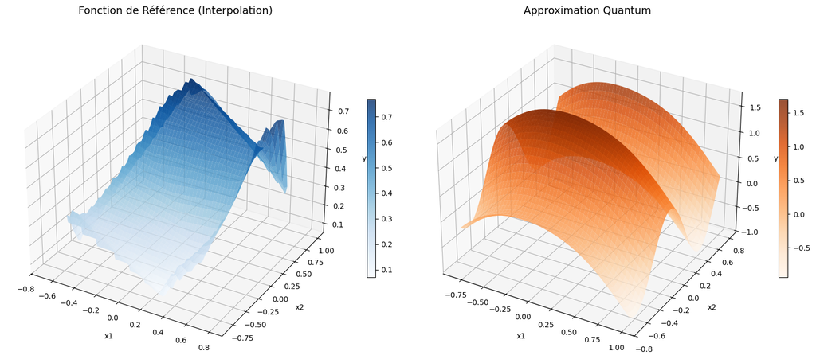

```python
import numpy as np
import matplotlib.pyplot as plt
from mpl_toolkits.mplot3d import Axes3D
from sklearn.datasets import load_iris
from sklearn.decomposition import PCA
from scipy.interpolate import griddata

def plot_3d_function_comparison(model, X, y):
    # Création d'une grille régulière basée sur les bornes des 2 composantes issu de PCA
    x1_min, x1_max = X[:, 0].min(), X[:, 0].max()
    x2_min, x2_max = X[:, 1].min(), X[:, 1].max()
    x1_lin = np.linspace(x1_min, x1_max, 50)
    x2_lin = np.linspace(x2_min, x2_max, 50)
    X1, X2 = np.meshgrid(x1_lin, x2_lin)

    # Calcul de l'approximation fournie par le modèle quantique sur chacune des combinaisons (x1, x2)
    approx_Z = np.zeros_like(X1)
    for i in range(X1.shape[0]):
        for j in range(X1.shape[1]):
            input_val = np.array([X1[i, j], X2[i, j]]).reshape(1, -1)
            approx_Z[i, j] = model.forward(input_val)

    # Surface de référence obtenue par interpolation des données réelles sur la grille
    ref_Z = griddata(X, y, (X1, X2), method='linear')

    # Création des figures 3D pour comparer les surfaces
    fig = plt.figure(figsize=(16, 7))

    # Surface de la fonction de référence (interpolée)
    ax1 = fig.add_subplot(121, projection="3d")
    surf1 = ax1.plot_surface(X1, X2, ref_Z, cmap="Blues", edgecolor="none", alpha=0.8)
    ax1.set_title("Fonction de Référence (Interpolation)", fontsize=14)
    ax1.set_xlabel("x1", labelpad=10)
    ax1.set_ylabel("x2", labelpad=10)
    ax1.set_zlabel("y", labelpad=10)
    fig.colorbar(surf1, ax=ax1, shrink=0.5)

    # Surface de l'approximation quantique
    ax2 = fig.add_subplot(122, projection="3d")
    surf2 = ax2.plot_surface(X2, X1, approx_Z, cmap="Oranges", edgecolor="none", alpha=0.8)
    ax2.set_title("Approximation Quantum", fontsize=14)
    ax2.set_xlabel("x1", labelpad=10)
    ax2.set_ylabel("x2", labelpad=10)
    ax2.set_zlabel("y", labelpad=10)
    fig.colorbar(surf2, ax=ax2, shrink=0.5)

    plt.tight_layout()
    plt.show()
plot_3d_function_comparison(model,X2,y_approx)
```

## Augmentation de la nuance grâce aux qubits supplémentaires et à la PCA

En ajoutant des qubits supplémentaires pour représenter de nouvelles caractéristiques et en appliquant une analyse en composantes principales (PCA), on peut enrichir la finesse de l’approximation. Cette combinaison permet de capturer des dimensions latentes et des corrélations subtiles via des rotations quantiques adaptées aux axes principaux du dataset.

- **Profondeur accrue de modélisation**  
  chaque qubit additionnel étend l’espace de Hilbert, offrant une granularité plus fine pour représenter les variations des données.
- **Réduction de la dimensionnalité via PCA**
  la PCA sélectionne les directions les plus informatives $$\mathrm{PC}_1,\mathrm{PC}_2,\dots$$ avant encodage quantique, limitant l’explosion du nombre de qubits requis.
- **Complexité des états quantiques**  
  le nombre d’états superposés croît exponentiellement avec le nombre de qubits, impliquant des coûts de calcul et de contrôle significatifs.
- **Défis de linéarisation**  
  l’ajout de qubits et de composantes principales renforce le besoin de circuits non linéaires, complexifiant la réduction à des opérations strictement linéaires.

En définitive, l’extension du système par des qubits additionnels et l’intégration de la PCA renforcent la nuance de l’analyse, mais exigent une gestion rigoureuse de la complexité des états et une stratégie pour maîtriser la linéarisation des circuits.